# 171860607-白晋斌-实验过程

任务描述：有1500个样例数据（每⼀⾏为⼀个样例，每个样例中有⼗⼀列数据，其中第⼀列为样例 的类别，共四种A、B、C、D，其后⼗列为样例的输⼊特征）。分类任务是通过输⼊特征来预测样例 的类别。请完成下列⼯作:

1. ⽤降维算法将数据降为2维或者3维，并以不同的颜⾊表示各类别进⾏可视化。
2. 尝试⽐较不同的降维算法（如⾃⼰实现的PCA算法、sklearn中的PCA⽅法，以及其他可能的降维⽅法等）的结果差异，如通过可视化结果进⾏⽐较等。
3. （附加题）尝试对此数据进⾏分类（分类⽅法、评估⽅法⾃⾏选择），并报告分类结果。

```python
#首先第一问，降维
#这里采用PCA法降维
import pandas as pd
import numpy as np
import seaborn as sns
import matplotlib.pyplot as plt
import numpy as np
from sklearn import preprocessing
from sklearn.ensemble import RandomForestRegressor
from mpl_toolkits.mplot3d import Axes3D
from sklearn.decomposition import PCA


df=pd.read_csv('dataset.csv',header=None)
df=df.iloc[:,:-1]
argv=df.iloc[:,1:]

#PCA
from sklearn.decomposition import PCA
model = PCA(n_components=2)   #降到2维
model.fit(argv)                  #训练
newX=model.fit_transform(argv)   #降维后的数据  ###transform就会执行降维操作
print(model.explained_variance_ratio_)  #输出贡献率
#print(newX)                  #输出降维后的数据
#print(newX)

#newX=newX.transpose()
pltfig=df.iloc[:,:1]
#print('pltfig:',pltfig)
pd2=pd.DataFrame(newX)
#print('pd2:')
#print(pd2)
pltfig=pd.concat([pltfig,pd2],ignore_index=True,axis=1)
print(pltfig)
#pltfig=pltfig.groupby(pltfig[0])
#pltfig.plot('scatter')
```

```
[0.40964276 0.28260179]
      0         1         2
0     A -3.782051  4.314092
1     C  4.574375 -0.940067
2     A -5.047301  2.587624
3     C  4.462800 -0.685587
4     D  0.559821  0.296235
5     A -2.667560 -2.857246
6     A -5.376441 -2.714666
7     D  0.855368 -0.273845
8     A -5.468692 -2.157966
9     B  4.058186  0.660351
10    D -0.472546  2.499604
11    B  2.822205 -0.606574
12    D  0.208691 -0.319534
```

[output cut: 50 more lines]

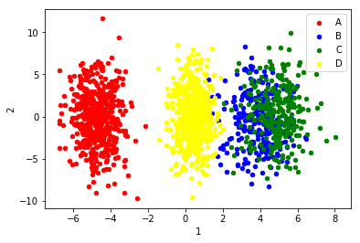

```python
#将上述结果绘图

colors = {'A':'red', 'B':'blue', 'C':'green','D':'yellow'}
fig, ax = plt.subplots()
grouped = pltfig.groupby(0)
for key, group in grouped:
    group.plot(ax=ax, kind='scatter', x=1, y=2, label=key, color=colors[key])
    #print(key)
plt.show()
```

```python
#第二问。尝试使用别的方法对原始数据进行降维

#独立成分分析法（ICA）是基于信息理论的一种常用的降维方法，其与PCA主要的不同是PCA是寻找不相关的变量，而ICA是挑选独立变量。同时PCA主要对于高斯分布数据比较有效，而ICA适用于其他分布。我们可以调用sklearn中的FastICA函数来进行数据独立成分分析。

from sklearn.decomposition import FastICA
ICA = FastICA(n_components=2, random_state=12)
X=ICA.fit_transform(argv)
print(X)


newX=model.fit_transform(argv)   #降维后的数据  ###transform就会执行降维操作
#print(ICA.explained_variance_ratio_)  #输出贡献率
#print(newX)                  #输出降维后的数据
#print(newX)

#newX=newX.transpose()
pltfig=df.iloc[:,:1]
#print('pltfig:',pltfig)
pd2=pd.DataFrame(X)
#print('pd2:')
#print(pd2)
pltfig=pd.concat([pltfig,pd2],ignore_index=True,axis=1)
print(pltfig)
#pltfig=pltfig.groupby(pltfig[0])
#pltfig.plot('scatter')
```

```
[[ 0.02362425  0.0363291 ]
 [-0.03040658 -0.00925115]
 [ 0.03288583  0.02277951]
 ...
 [-0.00263667  0.01640397]
 [-0.00444927  0.03871404]
 [ 0.03333993  0.04493332]]
      0         1         2
0     A  0.023624  0.036329
1     C -0.030407 -0.009251
2     A  0.032886  0.022780
3     C -0.029764 -0.007148
4     D -0.003897  0.002203
5     A  0.019191 -0.022220
6     A  0.037375 -0.020100
```

[output cut: 56 more lines]

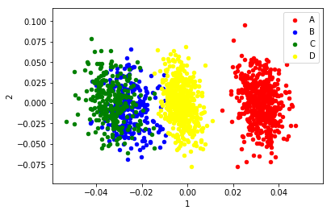

```python
#将上述结果绘图

colors = {'A':'red', 'B':'blue', 'C':'green','D':'yellow'}
fig, ax = plt.subplots()
grouped = pltfig.groupby(0)
for key, group in grouped:
    group.plot(ax=ax, kind='scatter', x=1, y=2, label=key, color=colors[key])
    #print(key)
plt.show()
```

```
0    0.250160
4    0.250067
1    0.084800
8    0.083508
2    0.082873
3    0.082576
9    0.081188
6    0.078952
7    0.067561
5    0.022136
dtype: float64
A
B
C
D
```

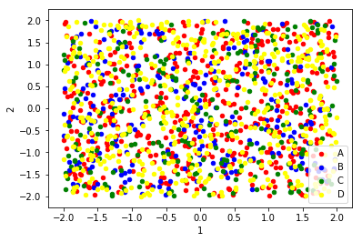

```python
#低方差滤波（Low Variance Filter）
#如果我们有一个数据集，其中某列的数值基本一致，也就是它的方差非常低，那么这个变量还有价值吗？和上一种方法的思路一致，我们通常认为低方差变量携带的信息量也很少，所以可以把它直接删除。
#放到实践中，就是先计算所有变量的方差大小，然后删去其中最小的几个。需要注意的一点是：方差与数据范围相关的，因此在采用该方法前需要对数据做归一化处理。


import pandas as pd
import numpy as np
import seaborn as sns
import matplotlib.pyplot as plt
import numpy as np
from sklearn import preprocessing
from sklearn.ensemble import RandomForestRegressor
from mpl_toolkits.mplot3d import Axes3D
from sklearn.decomposition import PCA


df=pd.read_csv('dataset.csv',header=None)
df=df.iloc[:,:-1]#数据清洗
#print(df)
argv=df.iloc[:,1:]

min_max_scaler = preprocessing.MinMaxScaler()
x_minmax = min_max_scaler.fit_transform(argv)
x_minmax=pd.DataFrame(x_minmax)
#print(x_minmax.var())
maxvar=x_minmax.var().sort_values(ascending=False)
print(maxvar)
#说明0号参数和4号参数对实验影响最大
df1=df.iloc[:,0:1]

df2=df.iloc[:,2:3]
df3=df.iloc[:,9:10]
#x_minmax=x_minmax.iloc[:,[0,4]]
res = pd.concat([df1,df2,df3],axis=1,ignore_index=True)
#print(x_minmax)
#print(res)
colors = {'A':'red', 'B':'blue', 'C':'green','D':'yellow'}
fig, ax = plt.subplots()
grouped = res.groupby(0)
for key, group in grouped:
    group.plot(ax=ax, kind='scatter', x=1, y=2, label=key, color=colors[key])
    print(key)
plt.show()
#区别不大，该方案作废
```

```
[[ 4.56980151 -0.94845145]
 [-5.04300069  2.60146603]
 [ 4.45716965 -0.6907984 ]
 ...
 [ 0.26441232  2.03669215]
 [ 0.36323018  4.79463975]
 [-5.27659298  5.32266664]]
```

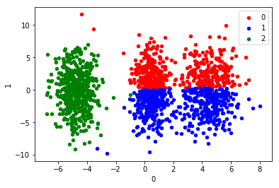

```python
#可以得出

#第三问 尝试对此数据进行分类
from sklearn.cluster import KMeans
import numpy as np
import pandas as pd
import matplotlib.pyplot as plt

#读取用于聚类的数据，并创建数据表
df=pd.DataFrame(pd.read_csv('dataset.csv',header=0))
df=df.iloc[:,:-1]
argv=df.iloc[:,1:]


from sklearn.decomposition import PCA
model = PCA(n_components=2)   #降到2维
model.fit(argv)                  #训练
newX=model.fit_transform(argv)   #降维后的数据  ###transform就会执行降维操作

loan_data=pd.DataFrame(newX)
#设置要进行聚类的字段
loan = np.array(loan_data[[0,1]])
print(loan)
#设置类别为3
clf=KMeans(n_clusters=3)
clf=clf.fit(loan)
loan_data['label']=clf.labels_#标记
#将数据代入到聚类模型中

#print(loan_data)

colors = {0:'red', 1:'blue', 2:'green',3:'yellow'}
fig, ax = plt.subplots()
grouped = loan_data.groupby('label')
for key, group in grouped:
    group.plot(ax=ax, kind='scatter', x=0, y=1, label=key, color=colors[key])
    #print(key)
plt.show()
```

[output not shown]